# Geog533 Lab 8

Nana Ama Obeng Nti

Complete the following exercises in Chapter 8 (Introduction to Regression Analysis) of the textbook [R] pages 247-250.

## Question 1

This is Exercise 1 in Chapter 8 of the Textbook [R].

A regression of weekly shopping trip frequency on annual income (data entered in thousands of dollars) is performed on data collected from 24 respondents. The results are summarized below:

- Intercept: 0.46
- Slope: 0.19

|  | Sum of squares | Degrees of freedom | Mean square | *F* |
| --- | --- | --- | --- | --- |
| Regression |  |  |  |  |
| Residual | 1.7 |  |  |  |
| Total | 2.3 |  |  |  |

### Question 1(a)

Fill in the blanks in the ANOVA table.

```r
n <- 24
SSR <- 1.7
SST <- 2.3
SSM <- SST - SSR
df1 <- 1
df2 <- n - 2
df3 <- n - 1
MMS <- SSM / df1
RMS <-  SSR / df2
F <- MMS / RMS
```

|  | Sum of squares | Degrees of freedom | Mean square | *F* |
| --- | --- | --- | --- | --- |
| Regression | 0.6 | 1 | 0.6 | 7.7647059 |
| Residual | 1.7 | 22 | 0.0772727 |  |
| Total | 2.3 | 23 |  |  |

### Question 1(b)

What is the predicted number of weekly shopping trips for someone making $50,000/year?

```r
int <- 0.46
slp <- 0.19
yh <- int + slp * (50000/1000)
yh
```

```
[1] 9.96
```

### Question 1(c)

In words, what is the meaning of the coefficient 0.19?

```r
print("Coefficient of 0.19 means that, the predicted weekly shopping trips frequency increases by 0.19 for every increase in annunal income of $1000")
```

```
[1] "Coefficient of 0.19 means that, the predicted weekly shopping trips frequency increases by 0.19 for every increase in annunal income of $1000"
```

### Question 1(d)

Is the regression coefficient significantly different from zero? How do you know?

```r
F.crit <- qf(0.95,df1,df2)
F.crit
```

```
[1] 4.30095
```

```r
if(F>F.crit) {
  print("We reject the null hypothesis")
} else {
  print("We cannot the null hypothesis")
}
```

```
[1] "We reject the null hypothesis"
```

```r
print("Since the F is greater than F.crit we reject the null hypothesis, thus, the regression coefficient is significantly different from zero")
```

```
[1] "Since the F is greater than F.crit we reject the null hypothesis, thus, the regression coefficient is significantly different from zero"
```

### Question 1(e)

What is the value of the correlation coefficient?

```r
R2 <- SSM / SST
R2
```

```
[1] 0.2608696
```

```r
r <-  sqrt(R2)
r
```

```
[1] 0.5107539
```

## Question 2

This is Exercise 6 in Chapter 8 of the Textbook [R].

The following data are collected in an effort to determine whether snowfall is dependent upon elevation:

| Snowfall (inches) | Elevation (feet) |
| --- | --- |
| 36 | 400 |
| 78 | 800 |
| 11 | 200 |
| 45 | 675 |

Using R, show your work on exercises (a) through (g).

### Question 2(a)

Find the regression coefficients (the intercept and the slope coefficient).

```r
elevation <- c(400,800,200,675)
snowfall <- c(36,78,11,45)
Reg <- lm(snowfall~elevation)
summary(Reg)
```

```
Call:
lm(formula = snowfall ~ elevation)

Residuals:
       1        2        3        4
  4.9772   8.3172  -0.6928 -12.6016

Coefficients:
            Estimate Std. Error t value Pr(>|t|)
(Intercept) -7.63721   13.67764  -0.558   0.6328
elevation    0.09665    0.02403   4.022   0.0566 .
---
Signif. codes:  0 ‘***’ 0.001 ‘**’ 0.01 ‘*’ 0.05 ‘.’ 0.1 ‘ ’ 1

Residual standard error: 11.25 on 2 degrees of freedom
Multiple R-squared:  0.8899,    Adjusted R-squared:  0.8349
F-statistic: 16.17 on 1 and 2 DF,  p-value: 0.05663
```

```r
intercept.slope <- Reg$coefficients
intercept.slope
```

```
(Intercept)   elevation
-7.63720599  0.09665004
```

```r
print("Intercept = -7.63721")
```

```
[1] "Intercept = -7.63721"
```

```r
print("Slope = 0.09665")
```

```
[1] "Slope = 0.09665"
```

### Question 2(b)

Estimate the standard error of the residuals about the regression line.

```r
anova(Reg)
```

```
Analysis of Variance Table

Response: snowfall
          Df  Sum Sq Mean Sq F value  Pr(>F)
elevation  1 2047.77 2047.77  16.173 0.05663 .
Residuals  2  253.23  126.61
---
Signif. codes:  0 ‘***’ 0.001 ‘**’ 0.01 ‘*’ 0.05 ‘.’ 0.1 ‘ ’ 1
```

```r
n <- 4
SSR <- 253.23
st.err <- sqrt(SSR / (n-2))
st.err
```

```
[1] 11.25233
```

### Question 2(c)

Test the hypothesis that the regression coefficient associated with the independent variables is equal to zero. Also place a 95% confidence interval on the regression coefficient.

```r
summary(Reg)
```

```
Call:
lm(formula = snowfall ~ elevation)

Residuals:
       1        2        3        4
  4.9772   8.3172  -0.6928 -12.6016

Coefficients:
            Estimate Std. Error t value Pr(>|t|)
(Intercept) -7.63721   13.67764  -0.558   0.6328
elevation    0.09665    0.02403   4.022   0.0566 .
---
Signif. codes:  0 ‘***’ 0.001 ‘**’ 0.01 ‘*’ 0.05 ‘.’ 0.1 ‘ ’ 1

Residual standard error: 11.25 on 2 degrees of freedom
Multiple R-squared:  0.8899,    Adjusted R-squared:  0.8349
F-statistic: 16.17 on 1 and 2 DF,  p-value: 0.05663
```

```r
print("Since P-value (0.05663) is greater than 0.05 we accept the null hypothesis that the regression coefficient associated with the independent variables is equal to zero.")
```

```
[1] "Since P-value (0.05663) is greater than 0.05 we accept the null hypothesis that the regression coefficient associated with the independent variables is equal to zero."
```

```r
confint(Reg)
```

```
                    2.5 %     97.5 %
(Intercept) -66.487337152 51.2129252
elevation    -0.006754067  0.2000541
```

### Question 2(d)

Find the value of $r^2$.

```r
R2 <- summary(Reg)
R2
```

```
Call:
lm(formula = snowfall ~ elevation)

Residuals:
       1        2        3        4
  4.9772   8.3172  -0.6928 -12.6016

Coefficients:
            Estimate Std. Error t value Pr(>|t|)
(Intercept) -7.63721   13.67764  -0.558   0.6328
elevation    0.09665    0.02403   4.022   0.0566 .
---
Signif. codes:  0 ‘***’ 0.001 ‘**’ 0.01 ‘*’ 0.05 ‘.’ 0.1 ‘ ’ 1

Residual standard error: 11.25 on 2 degrees of freedom
Multiple R-squared:  0.8899,    Adjusted R-squared:  0.8349
F-statistic: 16.17 on 1 and 2 DF,  p-value: 0.05663
```

```r
print("R2 = 0.8899")
```

```
[1] "R2 = 0.8899"
```

### Question 2(e)

Make a table of the observed values, predicted values, and the residuals.

```r
library(knitr)
df <- data.frame(elevation,snowfall)
df$predict <- Reg$fitted.values
df$residuals <- Reg$residuals
kable(df)
```

| elevation | snowfall | predict | residuals |
| --- | --- | --- | --- |
| 400 | 36 | 31.02281 | 4.9771917 |
| 800 | 78 | 69.68282 | 8.3171775 |
| 200 | 11 | 11.69280 | -0.6928011 |
| 675 | 45 | 57.60157 | -12.6015681 |

### Question 2(f)

Prepare an analysis of variance table portraying the regression results.

```r
anv <- anova(Reg)
anv
```

```
Analysis of Variance Table

Response: snowfall
          Df  Sum Sq Mean Sq F value  Pr(>F)
elevation  1 2047.77 2047.77  16.173 0.05663 .
Residuals  2  253.23  126.61
---
Signif. codes:  0 ‘***’ 0.001 ‘**’ 0.01 ‘*’ 0.05 ‘.’ 0.1 ‘ ’ 1
```

```r
ssm <- anv["Sum Sq"][[1]][1]
ssr <- anv["Sum Sq"][[1]][2]
sst <- SSM + SSR
df.1 <- anv["Df"][[1]][1]
df.2 <- anv["Df"][[1]][2]
df.3 <- df.1 + df.2
mms <- anv["Mean Sq"][[1]][1]
rms <- anv["Mean Sq"][[1]][2]
F.v <- anv["F value"][[1]][1]
```

[output not shown]

### Question 2(g)

Graph the data and the regression line.

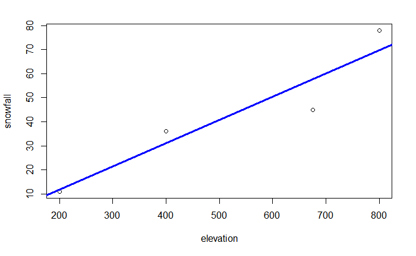

```r
plot(elevation, snowfall)
abline(Reg,col="blue",lwd=3)
```

## Question 3

This is Exercise 10 in Chapter 8 of the Textbook [R].

Use R and the [Milwaukee dataset](http://spatial.binghamton.edu/geog533/data/Milwaukee_Sales.csv) to:

### Problem

perform a regression using sales price as the dependent variable and lot size as the independent variable.

### Solution

```r
url = "http://spatial.binghamton.edu/geog533/data/Milwaukee_Sales.csv"
df <- read.csv(url,header = TRUE)
reg <- lm(df$SalePrice~df$LotSize)
summary(reg)
```

```
Call:
lm(formula = df$SalePrice ~ df$LotSize)

Residuals:
    Min      1Q  Median      3Q     Max
-144724  -42205  -14553   20987  808570

Coefficients:
             Estimate Std. Error t value Pr(>|t|)
(Intercept) 9.298e+04  5.249e+03  17.715  < 2e-16 ***
df$LotSize  6.443e+00  7.835e-01   8.223 4.37e-16 ***
---
Signif. codes:  0 ‘***’ 0.001 ‘**’ 0.01 ‘*’ 0.05 ‘.’ 0.1 ‘ ’ 1

Residual standard error: 83090 on 1447 degrees of freedom
Multiple R-squared:  0.04464,   Adjusted R-squared:  0.04398
F-statistic: 67.62 on 1 and 1447 DF,  p-value: 4.374e-16
```

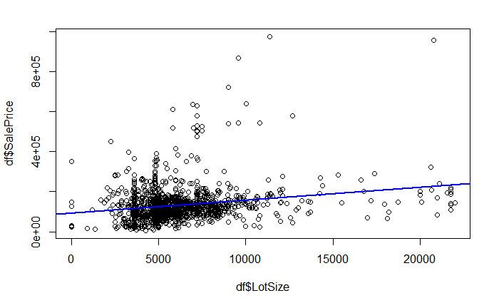

```r
plot(df$LotSize,df$SalePrice)
abline(reg,col="blue",lwd=2)
```

## Question 4

This is Exercise 11 in Chapter 8 of the Textbook [R].

Use R and the Hypothetical [UK Housing Prices dataset](http://spatial.binghamton.edu/geog533/data/UK_Housing.csv) to:

### Question 4(a)

perform a regression using house price as the dependent variable, and number of bedrooms as the independent variable;

```r
url = "http://spatial.binghamton.edu/geog533/data/UK_Housing.csv"
df <- read.csv(url,header = TRUE)
reg <- lm(df$price~df$bedrooms)
summary(reg)
```

```
Call:
lm(formula = df$price ~ df$bedrooms)

Residuals:
   Min     1Q Median     3Q    Max
-39324 -11511  -3539   8461 107568

Coefficients:
            Estimate Std. Error t value Pr(>|t|)
(Intercept)  11254.1     2312.7   4.866 1.53e-06 ***
df$bedrooms  11892.6      876.5  13.568  < 2e-16 ***
---
Signif. codes:  0 ‘***’ 0.001 ‘**’ 0.01 ‘*’ 0.05 ‘.’ 0.1 ‘ ’ 1

Residual standard error: 17800 on 497 degrees of freedom
Multiple R-squared:  0.2703,    Adjusted R-squared:  0.2688
F-statistic: 184.1 on 1 and 497 DF,  p-value: < 2.2e-16
```

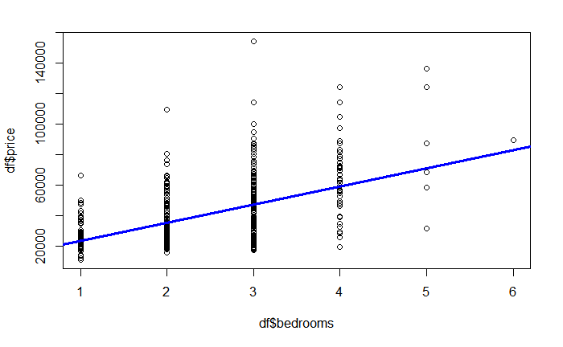

```r
plot(df$bedrooms,df$price)
abline(reg,col="blue",lwd=3)
```

### Question 4(b)

2. repeat part (a), using the number of bathrooms as the independent variable, and comment on the results.

```r
reg2 <- lm(df$price~df$bathrooms)
summary(reg2)
```

```
Call:
lm(formula = df$price ~ df$bathrooms)

Residuals:
   Min     1Q Median     3Q    Max
-34955 -15242  -5342  10908 114658

Coefficients:
             Estimate Std. Error t value Pr(>|t|)
(Intercept)     32729       3149  10.394  < 2e-16 ***
df$bathrooms     7113       2682   2.653  0.00824 **
---
Signif. codes:  0 ‘***’ 0.001 ‘**’ 0.01 ‘*’ 0.05 ‘.’ 0.1 ‘ ’ 1

Residual standard error: 20690 on 497 degrees of freedom
Multiple R-squared:  0.01396,   Adjusted R-squared:  0.01198
F-statistic: 7.036 on 1 and 497 DF,  p-value: 0.008245
```

[figure not shown]

```r
plot(df$bathrooms,df$price)
abline(reg,col="blue",lwd=3)
```

## Question 5

Download the hometown.csv, append your name and hometown coordinates to the csv, then use [leaflet](https://rstudio.github.io/leaflet/) to create a web map (10 pt.)

```r
library(leaflet)
df <- read.csv("hometown.csv",header = TRUE)
leaflet(data = df) %>% addTiles() %>%
  addMarkers(~df$longitude, ~df$latitude, popup = ~as.character(fullname), label = ~as.character(fullname), clusterOptions = markerClusterOptions())
```

[interactive chart not shown]